# Practice Problems 1: Hello Quarto

Author

Note that you must have the `tidyverse` package installed to run this document. If you have not installed this package, please type the command `install.packages("tidyverse")` into the RStudio console before continuing.

## Exercise 1

First, modify the “preamble” code above so that your name is in between the quotes where it currently says “Enter Your Name”.

## Exercise 2

Executable R code is entered in code chunks. Click the play button to see load the election2016 dataset and see the first six rows of observations. Once the document is rendered, it will show both the code and the output.

```r
library(tidyverse)
df_url="https://raw.githubusercontent.com/jmayberr/math133-stat-learning-fall2026/refs/heads/main/Datasets/election2016.csv"
election2016=read.csv(df_url)
head(election2016)
```

```
       state median.income unemployed metro high.school non.citizen white.pov
1    Alabama         42278      0.060  0.64       0.821        0.02      0.12
2     Alaska         67629      0.064  0.63       0.914        0.04      0.06
3    Arizona         49254      0.063  0.90       0.842        0.10      0.09
4   Arkansas         44922      0.052  0.69       0.824        0.04      0.12
5 California         60487      0.059  0.97       0.806        0.13      0.09
6   Colorado         60940      0.040  0.80       0.893        0.06      0.07
  income.ineq non.white trump.vote outcome
1       0.472      0.35       0.63     Red
2       0.422      0.42       0.53     Red
3       0.455      0.49       0.50     Red
4       0.458      0.26       0.60     Red
5       0.471      0.61       0.33    Blue
6       0.457      0.31       0.44    Blue
```

## Exercise 3

The code chunk below will create a scatterplot of *trump.vote* vs *non.white*. Change the x-aesthetic to a different variable in the dataset and modify the x-axis label accordingly.

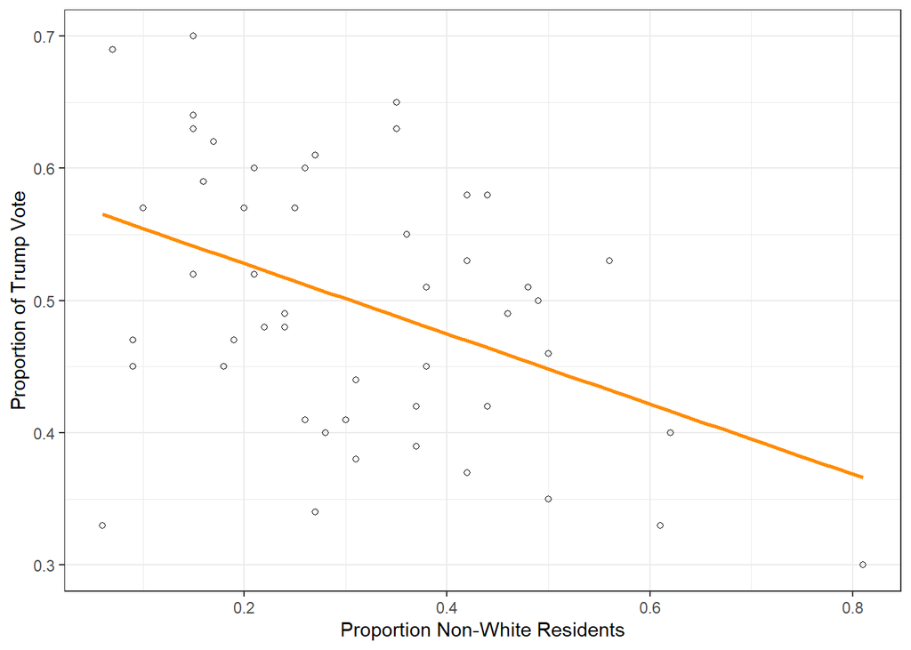

```r
ggplot(election2016,
       aes(x=non.white,y=trump.vote))+
  geom_point(shape=1)+
  labs(x="Proportion Non-White Residents",y="Proportion of Trump Vote")+
  geom_smooth(method="lm",se=FALSE,col="darkorange")+
  theme_bw()
```

## Exercise 4

Enter your own code chunk by either going to Insert –> Executable Cell –> R or typing / and selecting “R Code Chunk” or typing CTRL+ALT+I. Inside the cell type `print("One goal I have for this course is...")` and replace the … with a personal goal.

## Exercise 5

Now save this document as Practice1_*yourname*.qmd and click Render(or type CTRL+SHIFT+K) to create an html document of your solutions. Submit the html document to Canvas under the Week 1 Assignment and enjoy the rest of your first week of classes :)